# HW_1

### Analysis:

The histogram of Compactness for Opel shows that the most frequency happens at the range from 100 to 105. The histogram of Compactness for Opel is skewed to the left and therefore there is more observation on the right side. The histogram of Circularity for Opel shows its a bimodal and the two higest peak are between 36 to 38 and 53 to 56. The histogram of Circularity for Opel is bimodal skewed.

0.0989796365630487

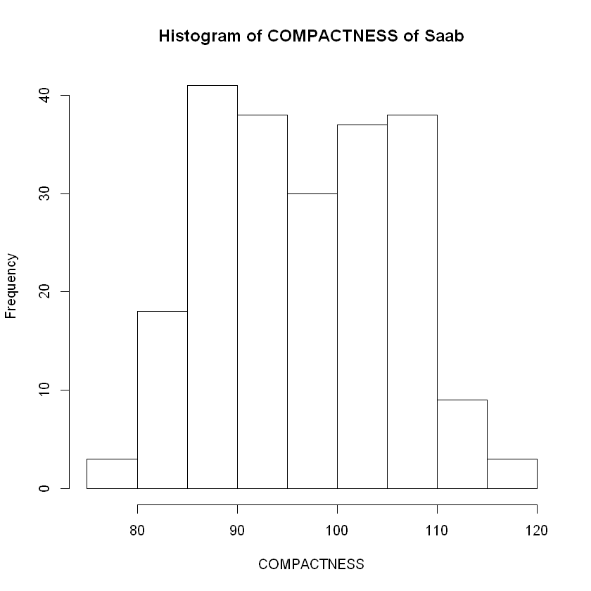

0.0989796365630487

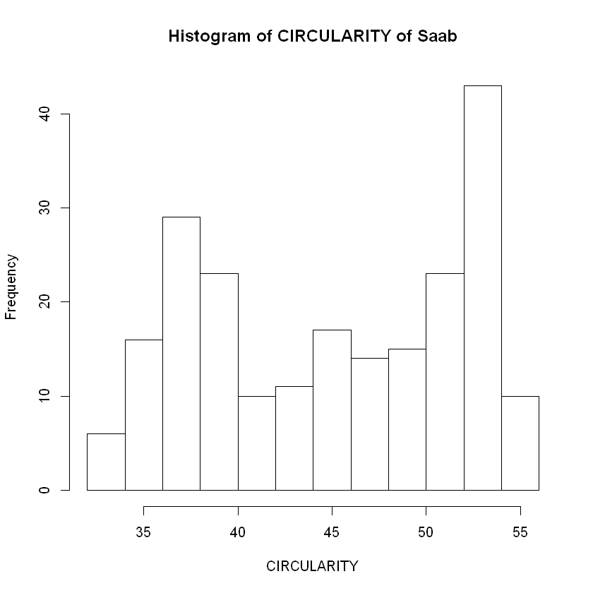

```r
saab_hist_data <- selected_data[selected_data$V19 == 'saab',]
hist(saab_hist_data$V1, main = "Histogram of COMPACTNESS of Saab", xlab = "COMPACTNESS", ylab = "Frequency")
skewness(saab_hist_data$V1)
hist(saab_hist_data$V2, , main = "Histogram of CIRCULARITY of Saab", xlab = "CIRCULARITY", ylab = "Frequency")
skewness(saab_hist_data$V1)
```

### Analysis:

The histogram of Compactness for Saab shows that the most frequency happens at the range from 85 to 90 and 105 to 110. The histogram of Compactness for Saab is bimodal skewed. The histogram of Circularity for Saab shows its a bimodal and the two higest peak are between 36 to 38 and 53 to 54. The histogram of Circularity for Saab is bimodat skewed.

0.575407673996567

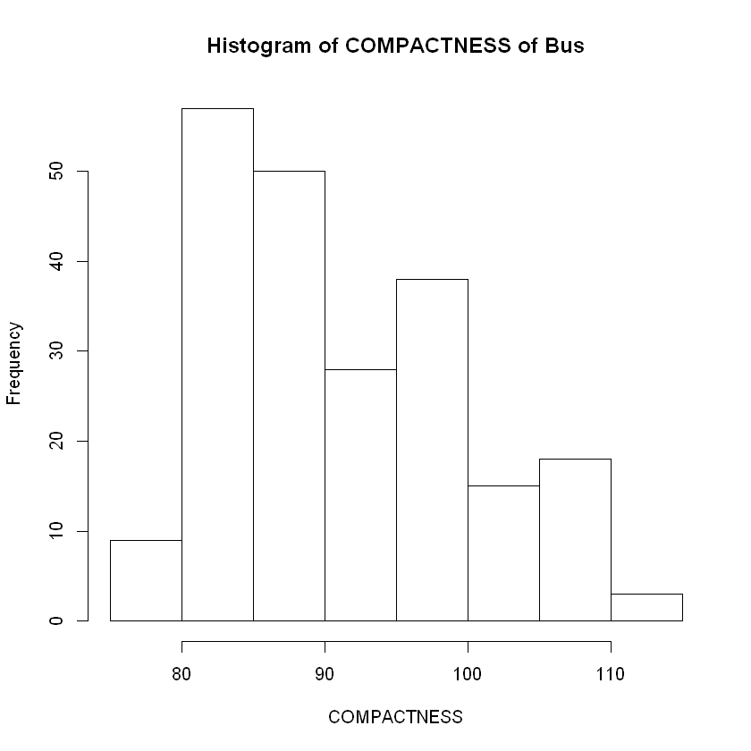

0.777615910060001

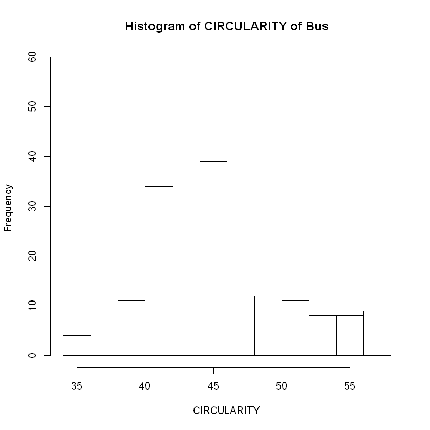

```r
bus_hist_data <- selected_data[selected_data$V19 == 'bus',]
hist(bus_hist_data$V1, main = "Histogram of COMPACTNESS of Bus", xlab = "COMPACTNESS", ylab = "Frequency")
skewness(bus_hist_data$V1)
hist(bus_hist_data$V2, main = "Histogram of CIRCULARITY of Bus", xlab = "CIRCULARITY", ylab = "Frequency")
skewness(bus_hist_data$V2)
```